# Amazon Ad-click prediction model

```python
import pandas as pd
import numpy as np
from sklearn.model_selection import train_test_split
from sklearn.preprocessing import LabelEncoder, StandardScaler
from sklearn.ensemble import RandomForestClassifier
from sklearn.metrics import accuracy_score, classification_report
import warnings

warnings.filterwarnings("ignore")
```

```python
train_data = pd.read_csv("train.csv")
test_data = pd.read_csv("test.csv")
```

```python
print(train_data.head())
print(train_data.info())
```

```
      Id  Full name  Age  Gender Device type Ad position Browsing history  \
0  10000  User10000   33  Female     Desktop      Bottom             News
1   5953   User8842   27  Female     Desktop         Top             News
2   5952   User9996   27    Male      Tablet      Bottom             News
3   5951   User9992   41  Female      Tablet         Top             News
4   5945   User9989   42    Male     Desktop        Side             News

  Time of day  Click
0   Afternoon      0
1       Night      0
2     Evening      0
3     Evening      0
4     Evening      0
<class 'pandas.core.frame.DataFrame'>
RangeIndex: 3662 entries, 0 to 3661
Data columns (total 9 columns):
 #   Column            Non-Null Count  Dtype
---  ------            --------------  -----
 0   Id                3662 non-null   int64
 1   Full name         3662 non-null   object
 2   Age               3662 non-null   int64
 3   Gender            3662 non-null   object
 4   Device type       3662 non-null   object
 5   Ad position       3662 non-null   object
 6   Browsing history  3662 non-null   object
 7   Time of day       3662 non-null   object
 8   Click             3662 non-null   int64
dtypes: int64(3), object(6)
memory usage: 257.6+ KB
None
```

```python
print(test_data.info())
```

```
<class 'pandas.core.frame.DataFrame'>
RangeIndex: 705 entries, 0 to 704
Data columns (total 8 columns):
 #   Column            Non-Null Count  Dtype
---  ------            --------------  -----
 0   Id                705 non-null    int64
 1   Full name         705 non-null    object
 2   Age               705 non-null    int64
 3   Gender            705 non-null    object
 4   Device type       705 non-null    object
 5   Ad position       705 non-null    object
 6   Browsing history  705 non-null    object
 7   Time of day       705 non-null    object
dtypes: int64(2), object(6)
memory usage: 44.2+ KB
None
```

```python
train_data = train_data.drop(columns=["Id", "Full name"], errors="ignore")
test_ids = test_data["Id"]  # Save test IDs for submission
test_data = test_data.drop(columns=["Id", "Full name"], errors="ignore")
```

```python
categorical_columns = ["Gender", "Device type", "Ad position", "Browsing history", "Time of day"]
label_encoders = {}

for col in categorical_columns:
    le = LabelEncoder()
    train_data[col] = le.fit_transform(train_data[col])
    test_data[col] = le.transform(test_data[col])
    label_encoders[col] = le
```

```python
train_data = train_data.fillna(train_data.median())
test_data = test_data.fillna(test_data.median())
```

```python
X = train_data.drop("Click", axis=1)
y = train_data["Click"]
```

```python
scaler = StandardScaler()
X = scaler.fit_transform(X)
test_data = scaler.transform(test_data)
```

```python
X_train, X_val, y_train, y_val = train_test_split(X, y, test_size=0.2, random_state=42)
```

```python
model = RandomForestClassifier(random_state=42, n_estimators=100)
model.fit(X_train, y_train)
```

```
RandomForestClassifier(random_state=42)
```

```python
y_pred = model.predict(X_val)
print("Validation Accuracy:", accuracy_score(y_val, y_pred))
print(classification_report(y_val, y_pred))
```

```
Validation Accuracy: 0.922237380627558
              precision    recall  f1-score   support

           0       0.94      0.90      0.92       345
           1       0.91      0.95      0.93       388

    accuracy                           0.92       733
   macro avg       0.92      0.92      0.92       733
weighted avg       0.92      0.92      0.92       733
```

```python
test_predictions = model.predict(test_data)
submission = pd.DataFrame({"Id":test_ids, "Click": test_predictions})
submission.to_csv("submission.csv", index=False)
```

```python
print("Submission file created: submission.csv")
```

```
Submission file created: submission.csv
```

```python
print(submission.head())
```

```
     Id  Click
0  9984      0
1  9978      1
2  9974      0
3  9967      0
4  9966      0
```

```python
misclassified = X_val[y_val != y_pred]
print(misclassified)
```

[output not shown]

[output cut: 59 more lines]

[output not shown]

```python
from xgboost import XGBClassifier
from sklearn.metrics import accuracy_score, classification_report

model = XGBClassifier(random_state=42)
model.fit(X_train, y_train)

y_pred = model.predict(X_val)

print("Validation Accuracy:",
accuracy_score(y_val, y_pred))
print(classification_report(y_val,y_pred))
```

```
Validation Accuracy: 0.8949522510231923
              precision    recall  f1-score   support

           0       0.95      0.82      0.88       345
           1       0.86      0.96      0.91       388

    accuracy                           0.89       733
   macro avg       0.90      0.89      0.89       733
weighted avg       0.90      0.89      0.89       733
```

```python
pip install xgboost
```

```python
pip show xgboost
```

```
Name: xgboost
Version: 2.1.3
Summary: XGBoost Python Package
Home-page:
Author:
Author-email: Hyunsu Cho <chohyu01@cs.washington.edu>, Jiaming Yuan <jm.yuan@outlook.com>
License: Apache-2.0
Location: C:\Users\HP\Documents\Python Scripts\Lib\site-packages
Requires: numpy, scipy
Required-by:
```

```python
conda install -c conda-forge xgboost
```

[output not shown]

```python
from xgboost import XGBClassifier
print("XGBoost is installed and working!")
```

```
XGBoost is installed and working!
```

```python
from xgboost import XGBClassifier
model = XGBClassifier(random_state=42)
model.fit(X_train, y_train)
```

```
XGBClassifier(base_score=None, booster=None, callbacks=None,
              colsample_bylevel=None, colsample_bynode=None,
              colsample_bytree=None, device=None, early_stopping_rounds=None,
              enable_categorical=False, eval_metric=None, feature_types=None,
              gamma=None, grow_policy=None, importance_type=None,
              interaction_constraints=None, learning_rate=None, max_bin=None,
              max_cat_threshold=None, max_cat_to_onehot=None,
              max_delta_step=None, max_depth=None, max_leaves=None,
              min_child_weight=None, missing=nan, monotone_constraints=None,
              multi_strategy=None, n_estimators=None, n_jobs=None,
              num_parallel_tree=None, random_state=42, ...)
```

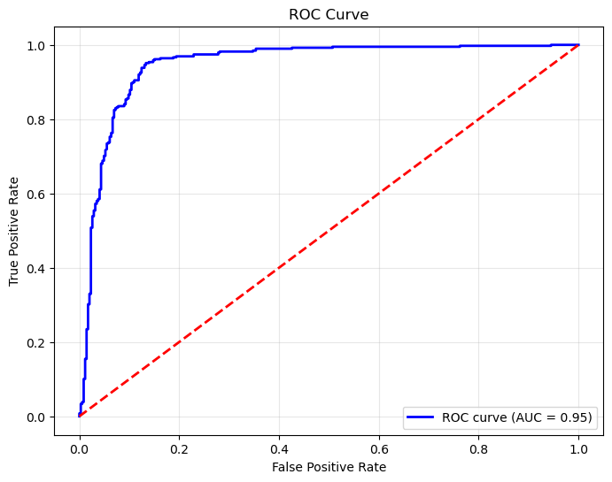

```python
from sklearn.metrics import roc_curve, auc
import matplotlib.pyplot as plt

# Get predicted probabilities
y_val_prob = model.predict_proba(X_val)[:, 1]

# Calculate ROC curve
fpr, tpr, thresholds = roc_curve(y_val, y_val_prob)
roc_auc = auc(fpr, tpr)

# Plot ROC curve
plt.figure(figsize=(8, 6))
plt.plot(fpr, tpr, color='blue', lw=2, label=f"ROC curve (AUC = {roc_auc:.2f})")
plt.plot([0, 1], [0, 1], color='red', linestyle='--', lw=2)
plt.xlabel("False Positive Rate")
plt.ylabel("True Positive Rate")
plt.title("ROC Curve")
plt.legend(loc="lower right")
plt.grid(alpha=0.3)
plt.show()
```

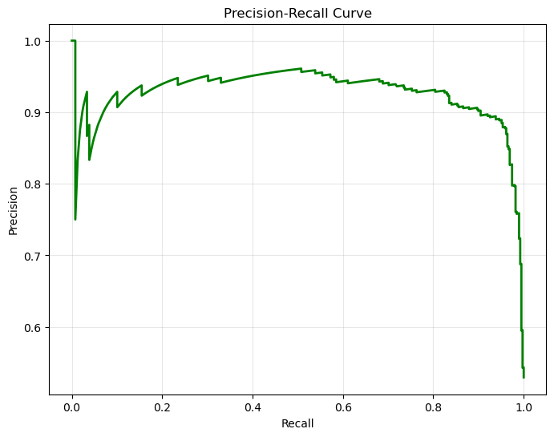

```python
from sklearn.metrics import precision_recall_curve

# Calculate Precision-Recall curve
precision, recall, thresholds = precision_recall_curve(y_val, y_val_prob)

# Plot Precision-Recall curve
plt.figure(figsize=(8, 6))
plt.plot(recall, precision, color='green', lw=2)
plt.xlabel("Recall")
plt.ylabel("Precision")
plt.title("Precision-Recall Curve")
plt.grid(alpha=0.3)
plt.show()
```

# Objective of the Model

The goal of the model is to classify each user into one of two categories:

1) Class 0: The user does not click on the advertisement. 2) Class 1: The user does click on the advertisement.

# Steps in the Code

1) Data Preprocessing:

- Removed irrelevant columns (id and full_name).
- Encoded categorical features (like gender, device_type, etc.).
- Standardized numerical features to ensure uniform scaling.

2) Model Training:

- The dataset was split into training (X_train, y_train) and validation (X_val, y_val) sets.
- A Random Forest Classifier was trained on the training data (X_train and y_train).
- Predictions (y_pred) were made for the validation set (X_val).

3) Model Predictions:

- The model outputs predictions (y_pred) for whether each user clicked on the ad (class 1) or did not click on the ad (class 0).

# Interpretation of Results

From the predictions and evaluation:

1) Validation Accuracy:

The model correctly predicted whether a user clicked or not for 92.22% of the validation dataset.

2) Detailed Metrics:

- For users who clicked the ad (class 1): The model identified 95% of them correctly (recall for class 1 = 0.95). Among the predicted "clicks," 91% were accurate (precision for class 1 = 0.91).
- For users who did not click the ad (class 0): The model identified 90% of them correctly (recall for class 0 = 0.90). Among the predicted "no clicks," 94% were accurate (precision for class 0 = 0.94).

# Practical Application

1) Optimize ad targeting: Show ads to users more likely to click.

2) Improve ad placement: Understand the best ad positions or times of day to display ads.

3) Increase ROI: Focus resources on users with a higher likelihood of interaction.